# python

```python
2 + 3
```

```
5
```

```python
3 + 4
```

```
7
```

4 + 5

```python
4 + 5
```

```
9
```

```python
9 + 1
```

```
10
```

```python
print("Jyoti")
```

```
Jyoti
```

```python
a = 3
b = 5
a + b
```

```
8
```

# Advanced Certification in AIML

## A Program by DataFolkz

### Introduction to Python

# Intro to Jupyter Notebook

- SHIFT + ENTER for EXECuting the CELL using Jupyter notebook Shortcuts in both modes:
  - Shift + Enter run the current cell,select below
  - Ctrl + Enter run selected cells
  - Alt + Enter run the current cell,insert below
  - Ctrl + S save and checkpoints

# Advanced Certification in AIML

## A Program by DataFolkz

### Introduction to Python

# Intro to Jupyter Notebook

- SHIFT + ENTER for EXECuting the CELL using Jupyter notebook Shortcuts in both modes:
- Shift + Enter run the current cell,select below
- Ctrl + Enter run selected cells
- Alt + Enter run the current cell,insert below
- Ctrl + S save and checkpoints

# Advanced Certification in AIML

## A Program by DataFolkz

### Introduction to Python

# Intro to Jupyter Notebook

- SHIFT + ENTER for EXECuting the CELL using Jupyter notebook Shortcuts in both modes:
- Shift + Enter run the current cell,select below
- Ctrl + Enter run selected cells
- Alt + Enter run the current cell,insert below
- Ctrl + S save and checkpoints
- esc + m for code to markdown
- esc + y for markdown to code

```python
print("Hello World")
```

```
Hello World
```

```python
a = 15

a
```

```
15
```

```python
My name is Jyoti
```

```
  File "<ipython-input-31-edc768e6817e>", line 1
    My name is Jyoti
          ^
SyntaxError: invalid syntax
```

```python
Firstnumber = 4
Firstnumber
```

```
4
```

```python
1stnumber = 5
```

```
  File "<ipython-input-35-dd93b17027e7>", line 1
    1stnumber = 5
            ^
SyntaxError: invalid syntax
```

```python
# Create a variable 'a' and assign 4 to that
a = 4
```

## Keywords

Keywords are the reserved words in Python.

We cannot use a keyword as a variable name, function name or any other identifier. They are used to define the syntax and structure of the Python language.

In Python, keywords are case sensitive.

All the keywords except True, False and None are in lowercase and they must be written as they are.

Keywords are the reserved words in Python.

We cannot use a keyword as a variable name, function name or any other identifier. They are used to define the syntax and structure of the Python language.

In Python, keywords are case sensitive.

There are 33 keywords in Python 3.7. This number can vary slightly over the course of time.

All the keywords except True, False and None are in lowercase and they must be written as they are.

Keywords Keywords are the reserved words in Python.

We cannot use a keyword as a variable name, function name or any other identifier. They are used to define the syntax and structure of the Python language.

In Python, keywords are case sensitive.

There are 33 keywords in Python 3.7. This number can vary slightly over the course of time.

All the keywords except True, False and None are in lowercase and they must be written as they are.

Keywords are the reserved words in Python.

We cannot use a keyword as a variable name, function name or any other identifier. They are used to define the syntax and structure of the Python language.

In Python, keywords are case sensitive.

There are 33 keywords in Python 3.7. This number can vary slightly over the course of time.

All the keywords except True, False and None are in lowercase and they must be written as they are.

[figure not shown]

[figure not shown]

[figure not shown]

Keywords Keywords are the reserved words in Python.

We cannot use a keyword as a variable name, function name or any other identifier. They are used to define the syntax and structure of the Python language.

In Python, keywords are case sensitive.

There are 33 keywords in Python 3.7. This number can vary slightly over the course of time.

All the keywords except True, False and None are in lowercase and they must be written as they are.

Keywords are the reserved words in Python.

We cannot use a keyword as a variable name, function name or any other identifier. They are used to define the syntax and structure of the Python language.

In Python, keywords are case sensitive.

There are 33 keywords in Python 3.7. This number can vary slightly over the course of time.

All the keywords except True, False and None are in lowercase and they must be written as they are.

Keywords Keywords are the reserved words in Python.

We cannot use a keyword as a variable name, function name or any other identifier. They are used to define the syntax and structure of the Python language.

In Python, keywords are case sensitive.

There are 33 keywords in Python 3.7. This number can vary slightly over the course of time.

All the keywords except True, False and None are in lowercase and they must be written as they are.

Keywords are the reserved words in Python.

We cannot use a keyword as a variable name, function name or any other identifier. They are used to define the syntax and structure of the Python language.

In Python, keywords are case sensitive.

There are 33 keywords in Python 3.7. This number can vary slightly over the course of time.

All the keywords except True, False and None are in lowercase and they must be written as they are.

[figure not shown]

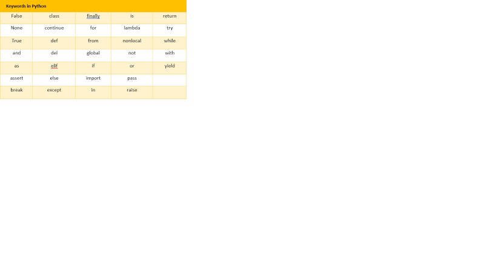

[figure not shown]

[figure not shown]